# **Insights and Visualizations**

The aim is to try and make sense out of the data cleaned from the wrangling act

```python
import pandas as pd
import numpy as np
import matplotlib.pyplot as plt
%matplotlib inline
```

```python
# Read and display the new dataframe
df = pd.read_csv('twitter_archive_master.csv')
df.head()
```

|  | tweet_id | timestamp | source | text | expanded_urls | rating_numerator | rating_denominator | name | jpg_url | img_num | ... | p1_dog | p2 | p2_conf | p2_dog | p3 | p3_conf | p3_dog | retweet | favorites | stages |
| --- | --- | --- | --- | --- | --- | --- | --- | --- | --- | --- | --- | --- | --- | --- | --- | --- | --- | --- | --- | --- | --- |
| 0 | 892420643555336193 | 2017-08-01 16:23:56+00:00 | <a href="http://twitter.com/download/iphone" r... | This is Phineas. He's a mystical boy. Only eve... | https://twitter.com/dog_rates/status/892420643... | 13 | 10 | Phineas | https://pbs.twimg.com/media/DGKD1-bXoAAIAUK.jpg | 1.0 | ... | False | bagel | 0.085851 | False | banana | 0.076110 | False | 7010 | 33824 | NaN |
| 1 | 892177421306343426 | 2017-08-01 00:17:27+00:00 | <a href="http://twitter.com/download/iphone" r... | This is Tilly. She's just checking pup on you.... | https://twitter.com/dog_rates/status/892177421... | 13 | 10 | Tilly | https://pbs.twimg.com/media/DGGmoV4XsAAUL6n.jpg | 1.0 | ... | True | Pekinese | 0.090647 | True | papillon | 0.068957 | True | 5302 | 29335 | NaN |
| 2 | 891815181378084864 | 2017-07-31 00:18:03+00:00 | <a href="http://twitter.com/download/iphone" r... | This is Archie. He is a rare Norwegian Pouncin... | https://twitter.com/dog_rates/status/891815181... | 12 | 10 | Archie | https://pbs.twimg.com/media/DGBdLU1WsAANxJ9.jpg | 1.0 | ... | True | malamute | 0.078253 | True | kelpie | 0.031379 | True | 3482 | 22065 | NaN |
| 3 | 891689557279858688 | 2017-07-30 15:58:51+00:00 | <a href="http://twitter.com/download/iphone" r... | This is Darla. She commenced a snooze mid meal... | https://twitter.com/dog_rates/status/891689557... | 13 | 10 | Darla | https://pbs.twimg.com/media/DF_q7IAWsAEuuN8.jpg | 1.0 | ... | False | Labrador_retriever | 0.168086 | True | spatula | 0.040836 | False | 7228 | 36947 | NaN |
| 4 | 891327558926688256 | 2017-07-29 16:00:24+00:00 | <a href="http://twitter.com/download/iphone" r... | This is Franklin. He would like you to stop ca... | https://twitter.com/dog_rates/status/891327558... | 12 | 10 | Franklin | https://pbs.twimg.com/media/DF6hr6BUMAAzZgT.jpg | 2.0 | ... | True | English_springer | 0.225770 | True | German_short-haired_pointer | 0.175219 | True | 7764 | 35317 | NaN |

5 rows × 22 columns

### A bar chart can be used to explore and visualize with dog stage counts of the dogs

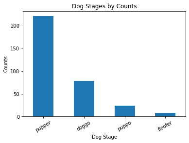

```python
df['stages'].value_counts().plot(kind='bar', rot=30);
plt.xlabel('Dog Stage');
plt.ylabel('Counts');
plt.title('Dog Stages by Counts');
```

A piechart can also be used to visualize the above

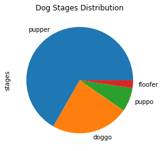

```python
# Plot a piechart for dog stages
df['stages'].value_counts().plot(kind = 'pie')
plt.title('Dog Stages Distribution');
```

It can be observed that the pupper stage is the most prevalent in the dataset as there are a lot more puppers than any other stage of dog.

### The data can be used to find out which dog stage is the most popular amongst the rest, that is, the stage that a lot of people fancied.

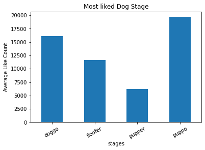

```python
def plot(value1, value2, label, title):
    df.groupby(value1)[value2].mean().plot(kind='bar', rot=30)
    plt.ylabel(label);
    plt.title(title);

plot('stages', 'favorites', 'Average Like Count', 'Most liked Dog Stage')
```

People seem to like dogs in the puppo stage a lot more than the others.

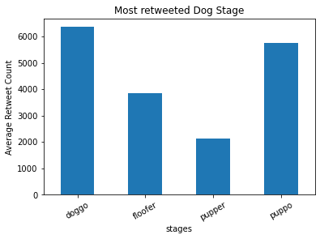

```python
plot('stages', 'retweet', 'Average Retweet Count', 'Most retweeted Dog Stage')
```

doggos had the most retweets closely followed by puppos. It can be observed that puppos are the most popular with people since they had a lot of likes and retweets from everyone.

### A scatter plot can also be drawn to explore the relationship between retweet and like counts

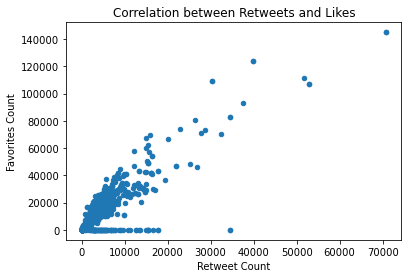

```python
# Scatter plot to show relationship between retweets and likes
df.plot(x = 'retweet', y = 'favorites', kind = 'scatter')
plt.xlabel('Retweet Count')
plt.ylabel('Favorites Count')
plt.title('Correlation between Retweets and Likes');
```

It can be observed that there is a positive correlation between retweets and likes, that is, any post that had a lot of likes had a lot of retweets as well. However, some tweets were retweeted a lot but had no likes.

# Conclusion

Once the data was gathered, assessed and cleaned successful various insights could be made from the data. This includes knowing with growth stage of dogs people liked more per the retweets and likes on each tweet about the dog. This also showed a positive correlation for retweets and likes on each tweet as the more people liked a tweet about a dog the more they retweeted that tweet. Finally, it was also observed that there were more dogs in the pupper stage than any other dog stage in the dataset.